# LR_1

Zubareva Marina

8 октября 2017 г

### Задание 1.

#### 1. Сгенерируйте 200 случайных значений из стандартного экспоненциального распределения и сохраните в вектор exp.1. Найдите среднее и стандартное отклонение из данных этого вектора.

```r
exp.1 <- rexp(n=200)
m.1 <- mean(exp.1) # среднее отклонение
sd.1 <- sd(exp.1) # стандартное отклонение
```

#### 2. Повторите, использовав следующие значения параметра λ: 0.1, 0.5, 5, 10, и сохраните результаты в векторы: exp.0.1, exp.0.5, exp.5, exp.10.

```r
# значение параметра 0.1
exp.0.1 <- rexp( n=200, rate=0.1)
m.0.1 <- mean(exp.0.1)
sd.0.1 <- sd(exp.0.1)

# значение параметра 0.5
exp.0.5 <- rexp(n=200, rate=0.5)
m.0.5 <- mean(exp.0.5)
sd.0.5 <- sd(exp.0.5)

# значение параметра 5
exp.5 <- rexp( n=200, rate=5)
m.5 <- mean(exp.5)
sd.5 <- sd(exp.5)

# значение параметра 10
exp.10 <- rexp(n=200, rate=10)
m.10 <- mean(exp.10)
sd.10 <- sd(exp.10)
```

#### 3. Функция plot() - общая функция для визуализации данных. Функция hist() принимает данные и раскладывает их по корзинам. Чтобы использовать эти функции, нужно для начала передать им данные, которые хотим визуализировать. Используйте функцию hist() для построения гистограммы полученного ранее стандартного распределения.

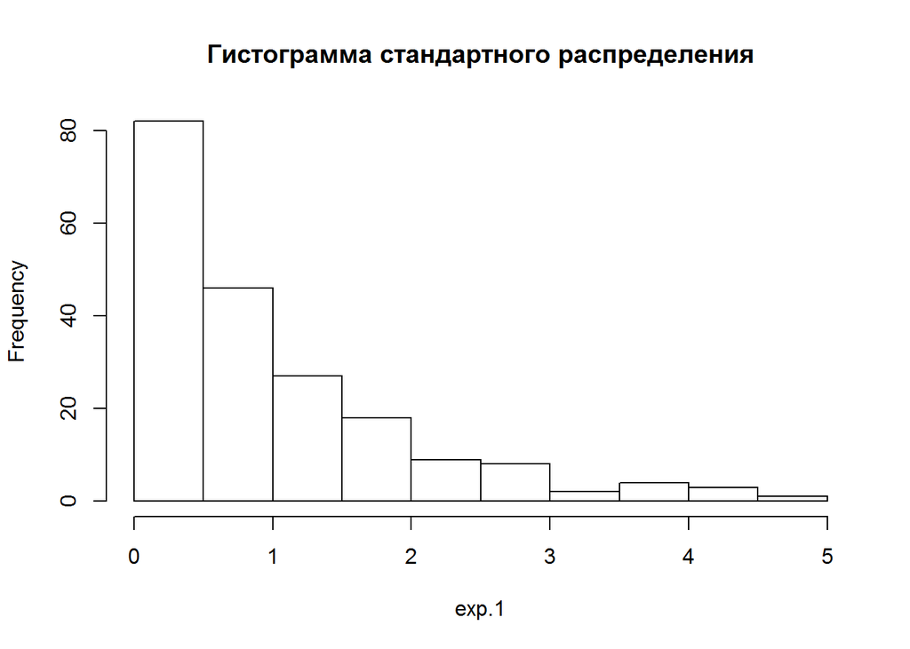

```r
hist(exp.1, main="Гистограмма стандартного распределения")
```

#### 4. Используйте функцию plot() с тем же самым вектором для построения графика значений в порядке следования.

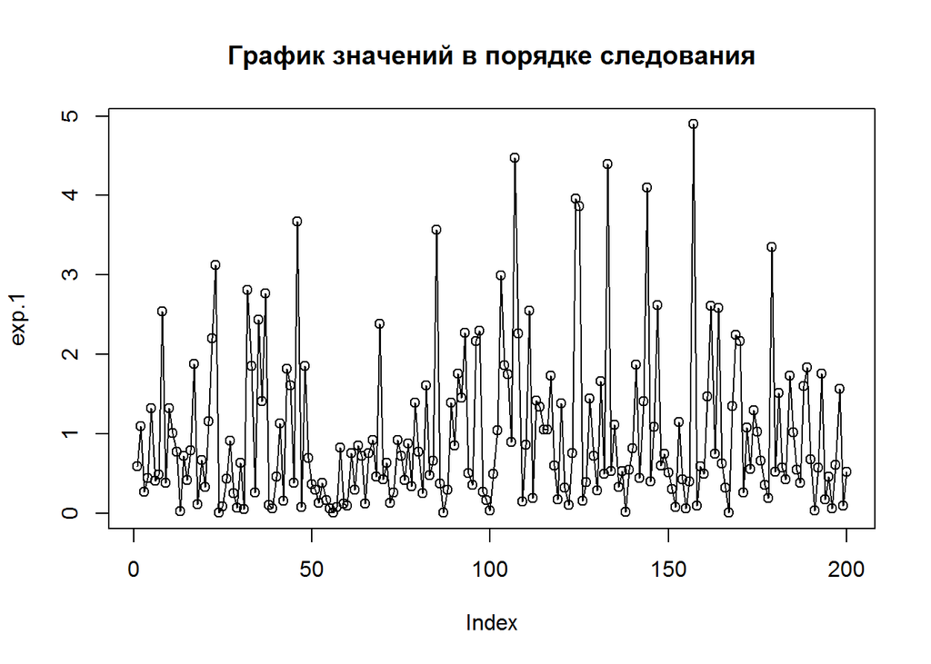

```r
plot(exp.1,main="График значений в порядке следования")
lines(exp.1)
```

#### 5. Используйте функцию plot() с любыми двумя полученными ранее векторами, чтобы получить диаграмму рассеяния (scatterplot) этих векторов относительно друг друга.

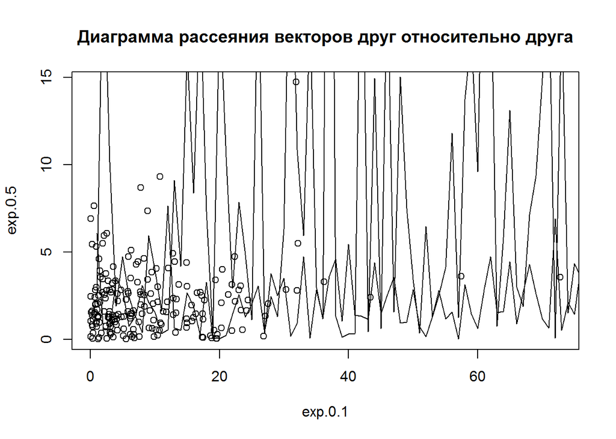

```r
plot(exp.0.1,exp.0.5,main="Диаграмма рассеяния векторов друг относительно друга")
lines(exp.0.1)
lines(exp.0.5)
```

#### 6. Теперь сравним свойства всех наших векторов. Для начала создадим вектор, содержащий средние значения каждого из 5 полученных ранее распределений в порядке их создания. Полученный вектор сохраним в переменную exp.means.

```r
exp.means <- c(m.1,m.0.1,m.0.5,m.5,m.10)
```

#### 7. Далее необходимо создать следующие диаграммы рассеяния:

- Вектор с пятью средними относительно каждого из пяти векторов с различными значениями λ.
- Вектор с пятью стандартными отклонениями относительно каждого из пяти векторов с различными значениями λ.
- Вектор с пятью средними относительно вектора с пятью стандартными отклонениями.

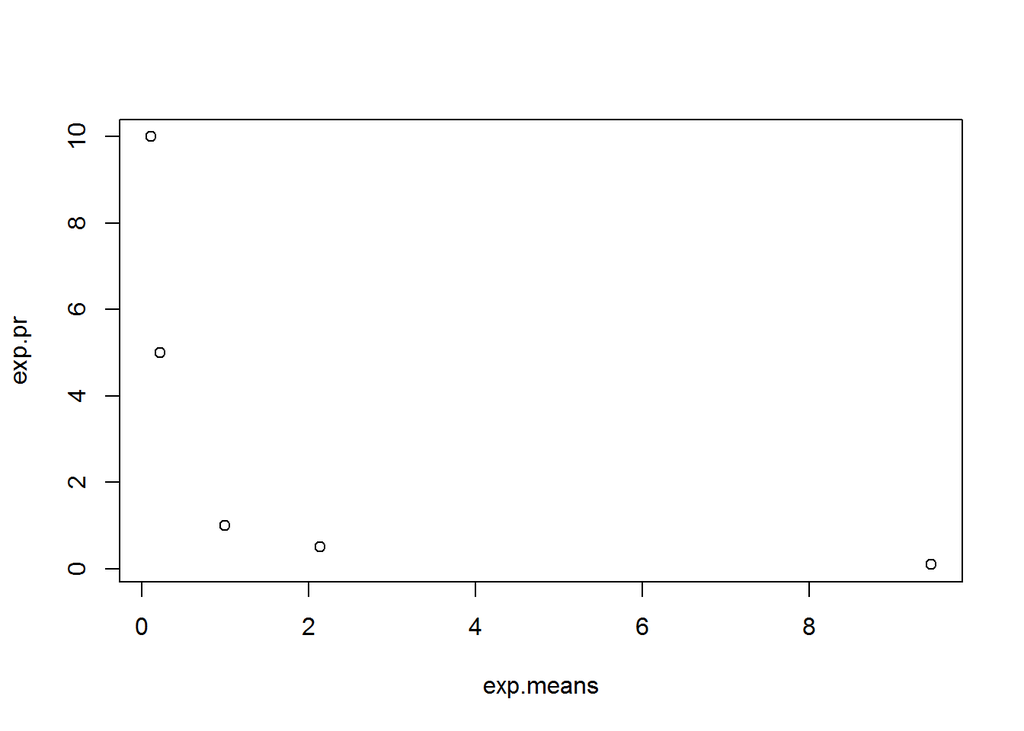

```r
exp.pr <- c(1, 0.1, 0.5, 5, 10)
exp.sds <- c(sd(exp.1), sd(exp.0.1), sd(exp.0.5), sd(exp.5), sd(exp.10))

plot(exp.means, exp.pr)
```

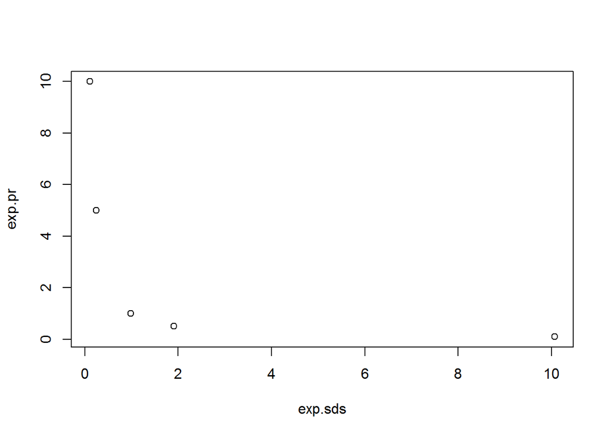

```r
plot(exp.sds, exp.pr)
```

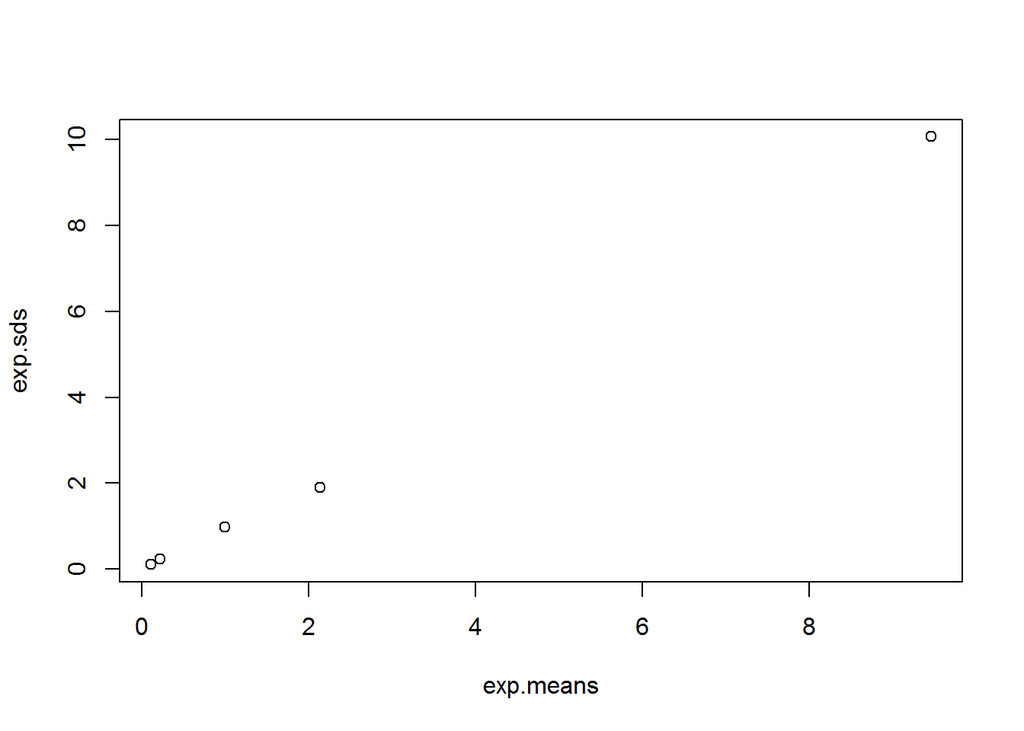

```r
plot(exp.means, exp.sds)
```

**Вывод**: Значения среднего и стандартного отклонения экспоненциального распределения обратно пропорциональны значению λ.А sd и mean прямо пропорциональны и имеют прямолинейную зависимость.

### Задание 2.

R достаточно производителен, чтобы вычислять относительно большие объёмы данных.

#### 1. Для демонстрации сгенерируйте 1100000 (1 млн. 100 тысяч) чисел из стандартного экспоненциального распределения и сохраните их в вектор huge.exp.1. Получите среднее и стандартное отклонение.

```r
huge.exp.1 <- rexp(1100000)
huge.exp.1.mean <- mean(huge.exp.1)
huge.exp.1.sd <- sd(huge.exp.1)
```

#### 2. Получите гистограмму huge.exp.1. Она соответствует функции 1 - e:^(-x)? Должна ли?

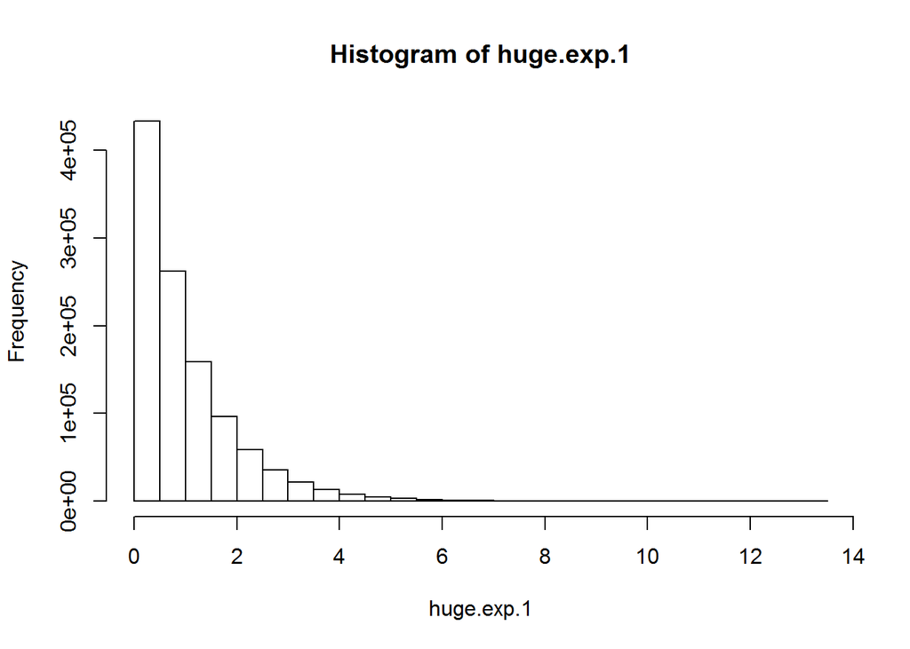

```r
hist(huge.exp.1)
```

#### 3. Получите среднее всех чисел из huge.exp.1 строго больших 1. Для проверки выборки может потребоваться новый вектор.

```r
mean(huge.exp.1[huge.exp.1>1])
```

```
## [1] 2.001286
```

#### 4. Получите матрицу huge.exp.1.mat, содержащую 1100 строк и 1000 колонок. Постройте гистограмму, использовав полученную матрицу. Что можно сказать о полученных данных?

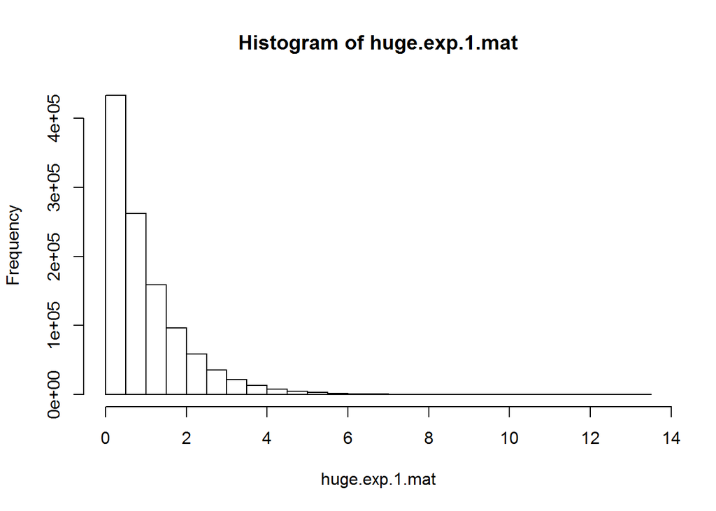

```r
huge.exp.1.mat = matrix(huge.exp.1, nrow = 1100, ncol = 1000)
hist(huge.exp.1.mat)
```

Гистограмма матрицы соответсвует гистограмме экспоненциального распределения.

#### 5. Рассчитайте среднее 137-й колонки из huge.exp.1.mat.

```r
mean(huge.exp.1.mat[,137])
```

```
## [1] 1.009284
```

#### 6. Найдите среднее всей 1000 колонок и сохраните их в вектор. Отобразите диаграмму средних значений колонок. Объясните, почему форма диаграммы отличается от виденных ранее.

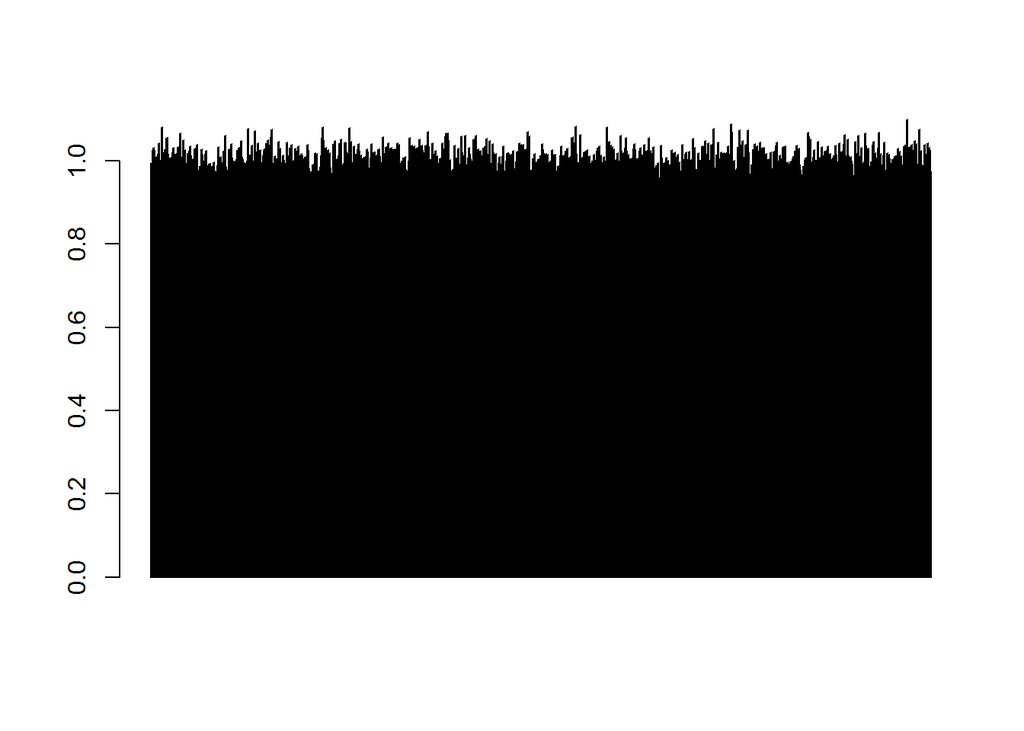

```r
mean.kas <- colMeans(huge.exp.1.mat)
barplot(mean.kas)
```

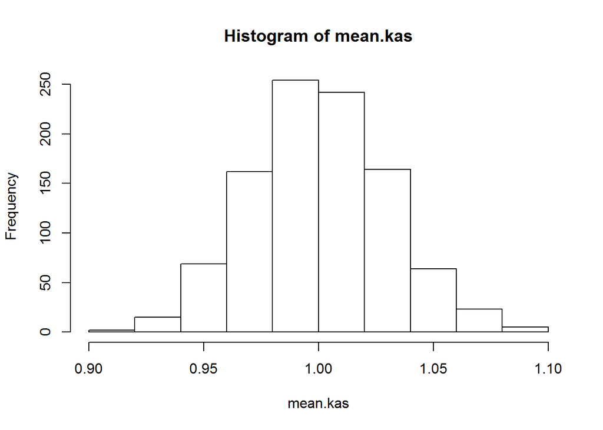

```r
hist(mean.kas)
```

Форма отличается, потому что мы имеем дело со средними значениями.

#### 7. Рассчитайте квадрат каждого значения из huge.exp.1 и найдите среднее и стандартное отклонение полученного вектора квадратов. Объясните отличие от соответствующих показателей вектора huge.exp.1. Вам может помочь формула, по которой R рассчитывает стандартное отклонение: sqrt(sum((x - mean(x))^2) / (n - 1)).

```r
huge.exp.1.square <- huge.exp.1 ^ 2
huge.exp.1.square.mean <- mean(huge.exp.1.square)
huge.exp.1.square.sd <- sd(huge.exp.1.square)

print(huge.exp.1.square.mean)
```

```
## [1] 2.004213
```

```r
print(huge.exp.1.square.sd)
```

```
## [1] 4.487208
```

С увеличением значений вектора среднее и стандартное отклонения увеличиваются.